# Introduction to StatComp18072

# Explanation

This exercise is analogous to the example 3.15(Poisson-Gamma mixture).I use the exponential function and Gamma function to generate a Exponential-Gamma mixture.

## Homework 2018-9-28

## Question 5.4

Write a function to compute a Monte Carlo estimate of the Beta(3, 3) cdf, and use the function to estimate F(x) for x =0 .1,0.2,…,0.9. Compare the estimates with the values returned by the pbeta function in R.

## Answer

As we all know,after calculation,the density distribution of Beta(3,3) is: f=30$x^2*(1-x)^2$.

Then I use the function to estimate F(x) for x=0.1,0.2,…0.9.

```r
x <- seq(.1, 0.9, length = 9)
m <- 10000
u <- runif(m)
cdf <- numeric(length(x))
for (i in 1:length(x)) {
  g <- 30*(x[i]^3)*(u^2)*((1-x[i]*u)^2)
  cdf[i] <- mean(g)
}
cdf
```

```
## [1] 0.008592357 0.058083943 0.163360891 0.317573689 0.499443676 0.680569543
## [7] 0.832733835 0.935209447 0.982066128
```

Last,I compare the estimates with the values returned by the pbeta function in R.The result shows that our Monte Carlo estimate is close to the theorical estimate values.

```r
Phi <- pbeta(x,3,3)
print(round(rbind(x, cdf, Phi), 3))
```

```
##      [,1]  [,2]  [,3]  [,4]  [,5]  [,6]  [,7]  [,8]  [,9]
## x   0.100 0.200 0.300 0.400 0.500 0.600 0.700 0.800 0.900
## cdf 0.009 0.058 0.163 0.318 0.499 0.681 0.833 0.935 0.982
## Phi 0.009 0.058 0.163 0.317 0.500 0.683 0.837 0.942 0.991
```

## Question 5.9

The Rayleigh density [156, (18.76)] is f(x)=$\frac{x}{\sigma^{2}}*e^{-\frac{x^{2}}{2\sigma^{2}}}$,x ??0,??>0. Implement a function to generate samples from a Rayleigh(??) distribution, using antithetic variables. What is the percent reduction in variance of (X+X’)/2 compared with (X1+X2)/2 for independent $X_{1}, X_{2}$?

## Answer

First,I use antithetic variables to implement a function to generate samples from a Rayleigh(??) distribution.By the way,sigma=1 in this problem.We can transform the distribution to calcalate E(Y).E(Y)=E(xy*e<sup>{-(xy)</sup>2/2},Y~U(0,1)

```r
MC.Phi <- function(x, R = 10000, antithetic = TRUE) {
  u <- runif(R/2)
  if (!antithetic) v <- runif(R/2) else
    v <- 1 - u
  u <- c(u, v)
  cdf <- numeric(length(x))
  for (i in 1:length(x)) {
    g <- x[i]*u*exp(-(x[i]*u)^2 / 2)
    cdf[i] <- mean(g)
  }
  cdf
}
```

Second,suppose X’ is the antithetic variable of X,and X1,X2 are independent variables with Rayleigh(??) distribution.

```r
MC.Phi <- function(x, R = 10000, antithetic = TRUE) {
  u <- runif(R/2)
  m <- 10000
  MC1 <- MC2 <- numeric(m)
  if (!antithetic) v <- runif(R/2) else
    v <- 1 - u
  u <- c(u, v)
  cdf <- numeric(length(x))
  for (i in 1:length(x)) {
    g <- (x[i]^2)*u*exp(-(x[i]*u)^2 / 2)
    cdf[i] <- mean(g)
  }
  cdf
}
x <- seq(1,3, length=10)
set.seed(123)
MC1 <- MC.Phi(x, anti = TRUE)
MC2 <- MC.Phi(x,anti=FALSE)
c(var(MC1),var(MC2))
```

```
## [1] 0.04313989 0.04461629
```

```r
print(c((var(MC2)-var(MC1))/var(MC2)))
```

```
## [1] 0.03309107
```

## Question 5.13

Find two importance functions f1 and f2 that are supported on (1,??) and are ??close?? to g(x)=exp(-(x^2)/2)*$\frac{x^{2}}{\sqrt{2*pi}}$,x>1. Which of your two importance functions should produce the smaller variance in estimating $\int_{1}^{\propto}$by importance sampling? Explain.

## Answer

I choose two functions which are corresponding with the requirement.

f1=$\frac{1}{\sqrt{2*\pi}}*e^{-{x+\frac{x^{2}}{2}}}$ f2=$\frac{1}{\sqrt{2*\pi}*x^{2}}$

```r
m <- 10000
theta.hat <- se <- numeric(5)
g <- function(x) { exp(-x^2 + log((x^2)/sqrt(2*pi)))}
x <- rexp(m)
fg <- sqrt(2*pi)* g(x)/exp(x-(x^2)/2)
theta.hat <- mean(fg)
se[1] <- sd(fg)
se[1]
```

```
## [1] 0.07980069
```

```r
m <- 10000
theta.hat <- se <- numeric(5)
g <- function(x) { exp(-x^2 + log((x^2)/sqrt(2*pi)))}
x <- runif(m)
fg<- g(x)/(sqrt(2*pi)*(x^2))
theta.hat[2] <- mean(fg)
se[2] <- sd(fg)
se[2]
```

```
## [1] 0.03196051
```

Next,I plot the density graph with f1 and f2 in the same rang of xlim.

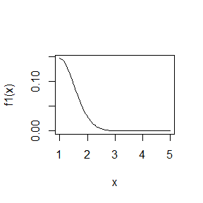

```r
f1 <- function(x) { exp(-x^2 + log((x^2)/sqrt(2*pi)))}
curve(f1,1,5)
```

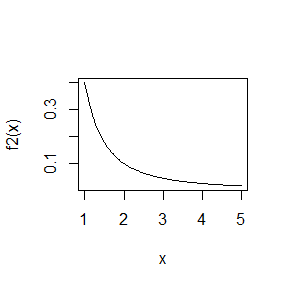

```r
f2 <- function(x){1/(sqrt(2*pi)*(x^2))}
curve(f2,1,5)
```

The result shows that the variance of f2 is smaller than f1.besides the graph of f2 is more smoothly than f1,I think it is the renson of variance difference.so as a whole,we can use f2 to reduce the variance of g(x).

## Question 5.14

Obtain a Monte Carlo estimate of g(x)=exp(-(x^2)/2)*$\frac{x^{2}}{\sqrt{2*pi}}$,x>1. by importance sampling

## Answer

Depending on the exercise 5.13,we can use f2=$\frac{1}{\sqrt{2*\pi}*x^{2}}$to estimate of g(x) by importance sampling.

```r
m <- 10000
theta.hat <- se <- numeric(5)
g <- function(x) { exp(-x^2 + log((x^2)/sqrt(2*pi)))}
x <- runif(m)
fg<- g(x)/(sqrt(2*pi)*(x^2))
theta.hat[2] <- mean(fg)
se[2] <- sd(fg)
se[2]
```

```
## [1] 0.03210281
```

## Homework 2018-11-02

## Question 7.1

Compute a jackknife estimate of the bias and the standard error of the correlation statistic in Example 7.2.

## Answer

```r
library(bootstrap)
data(law,package = "bootstrap")

 n <- nrow(law)
 y <- law$LSAT
 z <- law$GPA
 theta.hat <- cor(y,z)

 theta.jack <-numeric(n)
for (i in 1:n) {
  theta.jack[i] <- cor(y[-i],z[-i])
}
bias <- (n - 1)*(mean(theta.jack) - theta.hat)
se <- sqrt((n-1) * mean((theta.jack - mean(theta.jack))^2))
round(c(original=theta.hat,bias, se),3)
```

```
## original
##    0.776   -0.006    0.143
```

As for the result,we can see the bias is-0.006,the standerd error is 0.143.

## Question 7.5

Refer to Exercise 7.4. Compute 95% bootstrap con???dence intervals for the mean time between failures 1/?? by the standard normal, basic, percentile, and BCa methods. Compare the intervals and explain why they may di???er.

## Answer

```r
library(boot)
theta.boot <- function(x,i) {
  mean(x[i])
   }
x <- c(3,5,7,18,43,85,91,98,100,130,230,487)
boot.obj <- boot(x, statistic = theta.boot, R = 2000)
print(boot.obj)
```

```
##
## ORDINARY NONPARAMETRIC BOOTSTRAP
##
##
## Call:
## boot(data = x, statistic = theta.boot, R = 2000)
##
##
## Bootstrap Statistics :
##     original     bias    std. error
## t1* 108.0833 -0.5028333    37.63654
```

```r
print(boot.ci(boot.obj, type = c("basic", "norm", "perc")))
```

```
## BOOTSTRAP CONFIDENCE INTERVAL CALCULATIONS
## Based on 2000 bootstrap replicates
##
## CALL :
## boot.ci(boot.out = boot.obj, type = c("basic", "norm", "perc"))
##
## Intervals :
## Level      Normal              Basic              Percentile
## 95%   ( 34.8, 182.4 )   ( 25.7, 168.9 )   ( 47.3, 190.5 )
## Calculations and Intervals on Original Scale
```

```r
library(boot)
n <- length(x)
B <- 2000

x <- c(3,5,7,18,43,85,91,98,100,130,230,487)
theta.hat <- mean(x)
theta.b <- numeric(B)

for (b in 1:B) {
  i <- sample(1:n, size = n, replace = TRUE)
  y <- x[i]
  theta.b[b] <- mean(y)
}

boot.BCa <- function(x, th0, th, stat, conf = .95) {
  x <- as.matrix(x)
  n <- nrow(x)
  N <- 1:n
  alpha <- (1 + c(-conf, conf))/2
  zalpha <- qnorm(alpha)

 z0 <- qnorm(sum(th < th0) / length(th))
 th.jack <- numeric(n)
 for (i in 1:n) {
   J <- N[1:(n-1)]
   th.jack[i] <- stat(x[-i, ], J)
   }
 L <- mean(th.jack) - th.jack
 a <- sum(L^3)/(6 * sum(L^2)^1.5)

 adj.alpha <- pnorm(z0 + (z0+zalpha)/(1-a*(z0+zalpha)))
 limits <- quantile(th, adj.alpha, type=6)
 return(list("est"=th0, "BCa"=limits))
}

  stat <- function(x,i) {
  mean(x[i])
}

boot.BCa(x, th0 = theta.hat, th = theta.b, stat = stat)
```

```
## $est
## [1] 108.0833
##
## $BCa
##  6.23977% 99.50313%
##  57.48815 232.08814
```

## Question 7.8

Refer to Exercise 7.7. Obtain the jackknife estimates of bias and standard error of ?? ??.

## Answer

```r
library(bootstrap)
data(scor,package = "bootstrap")
n <- nrow(law)
v <- cov(scor)
E <- eigen(v)$value
theta.hat <- E[1]/sum(E)


theta.jack <- numeric(n)
for (i in 1:n) {
  scorstar <- scor[-i,]
  f <- eigen(cov(scorstar))$value
  theta.jack[i] <- f[1]/sum(f)
}
bias <- (n - 1)*(mean(theta.jack) - theta.hat)
se <- sqrt((n-1) * mean((theta.jack - mean(theta.jack))^2))
round(c(original=theta.hat,bias, se),3)
```

```
## original
##    0.619   -0.081    0.022
```

As for the result,we can see the bias is-0.081,the standerd error is 0.022.

## Question 7.11

In Example 7.18, leave-one-out (n-fold) cross validation was used to select the best ???tting model. Use leave-two-out cross validation to compare the models.

## Answer

Because of leave-two-out cross validation,so I extract two samples once to do this exercise.

```r
library(DAAG)
data(ironslag,package = "DAAG")
set.seed(1)
n <- length(ironslag$magnetic)
e1 <- e2 <- e3 <- e4 <- numeric(n)
e11 <- e21 <- e31 <- e41 <- numeric(n-1)
e12 <- e22 <- e32 <- e42 <- numeric(n-1)

for (k in 1:(n-1)) {
  y <- ironslag$magnetic[c(-k,-(k+1))]
  x <- ironslag$chemical[c(-k,-(k+1))]

  J1 <- lm(y ~ x)
  yhat11 <- J1$coef[1] + J1$coef[2] * ironslag$chemical[k]
  yhat12 <- J1$coef[1] + J1$coef[2] * ironslag$chemical[k+1]
  e11[k] <- ironslag$magnetic[k] - yhat11
  e12[k+1] <- ironslag$magnetic[k+1] - yhat12
  e1[k] <- e11[k]+e12[k+1]

  J2 <- lm(y ~ x + I(x^2))
  yhat21 <- J2$coef[1] + J2$coef[2] * ironslag$chemical[k] +
    J2$coef[3] * ironslag$chemical[k]^2
  yhat22 <- J2$coef[1] + J2$coef[2] * ironslag$chemical[k+1] +
    J2$coef[3] * ironslag$chemical[k+1]^2
  e21[k] <- ironslag$magnetic[k] - yhat21
  e22[k+1] <- ironslag$magnetic[k+1] - yhat22
  e2[k] <- e21[k]+e22[k+1]

  J3 <- lm(log(y) ~ x)
  logyhat31 <- J3$coef[1] + J3$coef[2] * ironslag$chemical[k]
  logyhat32 <- J3$coef[1] + J3$coef[2] * ironslag$chemical[k+1]
  yhat31 <- exp(logyhat31)
  yhat32 <- exp(logyhat32)
  e31[k] <- ironslag$magnetic[k] - yhat31
  e32[k+1] <- ironslag$magnetic[k+1] - yhat32
  e3[k] <- e31[k]+e32[k+1]

  J4 <- lm(log(y) ~ log(x))
  logyhat41 <- J4$coef[1] + J4$coef[2] * log(ironslag$chemical[k])
  logyhat42 <- J4$coef[1] + J4$coef[2] * log(ironslag$chemical[k+1])
  yhat41 <- exp(logyhat41)
  yhat42 <- exp(logyhat42)
  e41[k] <- ironslag$magnetic[k] - yhat41
  e42[k+1] <- ironslag$magnetic[k+1] - yhat42
  e4[k] <- e41[k]+e42[k+1]
}
 c(mean(e1^2), mean(e2^2),mean(e3^2), mean(e4^2))
```

```
## [1] 56.47917 47.74031 53.26205 62.05510
```

According to the prediction error criterion, Model 2, the quadratic model, would be the best ???t for the data.

In the orther hand,I disrupt the sample of ironslag,and then repeat the process again.

```r
library(DAAG)
data(ironslag,package = "DAAG")
set.seed(1)
z <- sample(ironslag,length(ironslag)) #disrupt the sample
n <- length(z$magnetic)
e1 <- e2 <- e3 <- e4 <- numeric(n)
e11 <- e21 <- e31 <- e41 <- numeric(n-1)
e12 <- e22 <- e32 <- e42 <- numeric(n-1)

for (k in 1:(n-1)) {
  y <- z$magnetic[c(-k,-(k+1))]
  x <- z$chemical[c(-k,-(k+1))]

  J1 <- lm(y ~ x)
  yhat11 <- J1$coef[1] + J1$coef[2] * z$chemical[k]
  yhat12 <- J1$coef[1] + J1$coef[2] * z$chemical[k+1]
  e11[k] <- z$magnetic[k] - yhat11
  e12[k+1] <- z$magnetic[k+1] - yhat12
  e1[k] <- e11[k]+e12[k+1]

  J2 <- lm(y ~ x + I(x^2))
  yhat21 <- J2$coef[1] + J2$coef[2] * z$chemical[k] +
    J2$coef[3] * z$chemical[k]^2
  yhat22 <- J2$coef[1] + J2$coef[2] * z$chemical[k+1] +
    J2$coef[3] * z$chemical[k+1]^2
  e21[k] <- z$magnetic[k] - yhat21
  e22[k+1] <- z$magnetic[k+1] - yhat22
  e2[k] <- e21[k]+e22[k+1]

  J3 <- lm(log(y) ~ x)
  logyhat31 <- J3$coef[1] + J3$coef[2] * z$chemical[k]
  logyhat32 <- J3$coef[1] + J3$coef[2] * z$chemical[k+1]
  yhat31 <- exp(logyhat31)
  yhat32 <- exp(logyhat32)
  e31[k] <- z$magnetic[k] - yhat31
  e32[k+1] <- z$magnetic[k+1] - yhat32
  e3[k] <- e31[k]+e32[k+1]

  J4 <- lm(log(y) ~ log(x))
  logyhat41 <- J4$coef[1] + J4$coef[2] * log(z$chemical[k])
  logyhat42 <- J4$coef[1] + J4$coef[2] * log(z$chemical[k+1])
  yhat41 <- exp(logyhat41)
  yhat42 <- exp(logyhat42)
  e41[k] <- z$magnetic[k] - yhat41
  e42[k+1] <- z$magnetic[k+1] - yhat42
  e4[k] <- e41[k]+e42[k+1]
}
 c(mean(e1^2), mean(e2^2),mean(e3^2), mean(e4^2))
```

```
## [1] 56.47917 47.74031 53.26205 62.05510
```

According to the prediction error criterion, Model 2, the quadratic model, would be the best ???t for the data.It is the same with method1.

## homework 2018-11-16

## Question 8.1

Implement the two-sample Cram??er-von Mises test for equal distributions as a permutation test. Apply the test to the data in Examples 8.1 and 8.2.

## Answer

```r
set.seed(1)

attach(chickwts)
x <- sort(as.vector(weight[feed == "soybean"]))
y <- sort(as.vector(weight[feed == "linseed"]))
detach(chickwts)


cramer <-function(x,y){ #compute the Cramer-von Mises statistic
  n <- length(x)
  m <- length(y)
  Fn <- ecdf(x)
  Gm <- ecdf(y)
  W2 <- ((m*n)/(m+n)^2)*
      (sum((Fn(x)-Gm(x))^2)+sum((Fn(y)-Gm(y))^2))
  W2
}


R <- 999
z <- c(x, y)
n <- length(x)
m <- length(y)
K <- 1:(m+n)
w2 <- numeric(R)

w2.0 <- cramer(x,y)


for (i in 1:R) {
  k <- sample(K, size = n, replace = FALSE)
  x1 <- z[k]
  y1 <- z[-k]
  w2[i] <- cramer(x1,y1)
  }
p <- mean(c(w2.0, w2) >= w2.0)

print(p)
```

```
## [1] 0.421
```

As for this result,we can see the P value of Cram??er-von Mises test is 0.421,so it does not support the alternative hypothesis that distributions di???er.

## Question

Design experiments for evaluating the performance of the NN, energy, and ball methods in various situations. (1)Unequal variances and equal expectations

2. Unequal variances and unequal expectations
3. Non-normal distributions: t distribution with 1 df (heavy-tailed distribution), bimodel distribution (mixture of two normal distributions)
4. Unbalanced samples (say, 1 case versus 10 controls)
5. Unbalanced samples (say, 1 case versus 10 controls) For this exercise,I had tried many mathods to do it,but unfortunately,these results aren’t well,so I can’t give answer this time.I will learn more to solve this problem later.

## Question 9.3

The standard Cauchy has the Cauchy(?? =1,??= 0) density. (Note that the standard Cauchy density is equal to the Student t density with one degree of freedom.)

## Answer

```r
set.seed(1)
f <- function(x, theta,eta) {
  stopifnot(theta > 0)
  return(1/(theta*pi*(1+((x-eta)/theta)^2)))
}
xt <- x[i-1]
y <-  xt+runif(1,-1,1)
m <- 10000
theta <- 1
eta <- 0
x <- numeric(m)
x[1] <- runif(1,-1,1)
k <- 0
u <- runif(m)

for (i in 2:m) {
  xt <- x[i-1]
  y <- xt+runif(1,min=-1,max=1)
  num <- f(y, theta,eta)*dnorm(xt,mean=y,sd=1)
  den <- f(xt, theta,eta)*dnorm(y,mean=xt,sd=1)
  if (u[i] <= num/den) x[i] <- y else {
    x[i] <- xt
    k <- k+1         #y is rejected
  }
}
print(k)
```

```
## [1] 1675
```

In this exercise, approximately 17% of the candidate points are rejected, so the chain is somewhat e???cient.

To see the generated sample as a realization of a stochastic process, we can plot the sample vs the time index. The following code will display a partial plot starting at time index 1500.

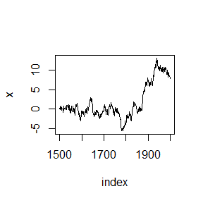

```r
index <- 1500:2000
y1 <- x[index]
plot(index, y1, type="l", main="", ylab="x")
```

The following code compares the quantiles of the target cauchy (1,0) distribution with the quantiles of the generated chain in a quantile-quantile plot (QQ plot).

```r
gene<- quantile(x[-(1:1000)],seq(0.1,0.9,0.1))
empi<-qt(seq(0.1,0.9,0.1),1)
rbind(gene,empi)
```

```
##            10%       20%        30%        40%          50%       60%
## gene -2.569783 -1.272012 -0.7253008 -0.3254927 -0.005523593 0.3115794
## empi -3.077684 -1.376382 -0.7265425 -0.3249197  0.000000000 0.3249197
##            70%      80%      90%
## gene 0.6881670 1.319415 3.312069
## empi 0.7265425 1.376382 3.077684
```

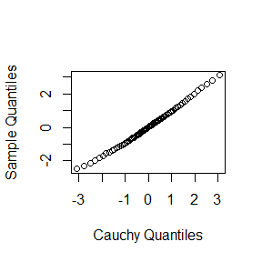

```r
b <- 1001     #discard the burnin sample
y <- x[b:m]
probs <- seq(0.1,0.9,0.01)
QR <- qt(probs,df=1)
Q <- quantile(x, probs)

qqplot(QR, Q, main="",
       xlab="Cauchy Quantiles", ylab="Sample Quantiles")
```

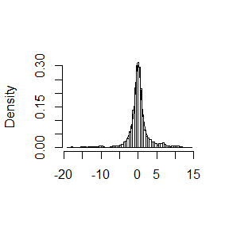

```r
hist(y, breaks="scott", main="", xlab="", freq=FALSE)
lines(QR, f(QR, 1,0))
```

The QQ plot is aninformal approachto assessing the goodness-of-???t of the generated sample with the target distribution. From the plot, it appears that the sample quantiles are in approximate agreement with the theoretical quantiles.

## Question 9.6

Rao [220, Sec. 5g] presented an example on genetic linkage of 197 animals in four categories (also discussed in [67, 106, 171, 266]). The group sizes are (125,18,20,34). Assume that the probabilities of the corresponding multinomial distribution are ($\frac{2+\theta}{4}\qquad,$,$\frac{1-\theta}{4}\qquad,$) Estimate the posterior distribution of ?? given the observed sample, using one of the methods in this chapter.

## Answer

```r
set.seed(1)

w <- .25   #width of the uniform support set
m <- 5000  #length of the chain
burn <- 1000  #burn-in time
total <- 197
x <- numeric(m)  #the chain
```

```r
group <- c(125,20,18,34)

prob <- function(y, group) {
  # computes (without the constant) the target density
  if (y < 0 || y >= 1)
    return (0)
  return(((2+y)/4)^group[1] *
           ((1-y)/4)^group[2] * ((1-y)/4)^group[3] *
           ((y/4)^group[4]))
}

u <- runif(m)          #for accept/reject step
v <- runif(m, -w, w)   #proposal distribution
x[1] <- 0.5
for (i in 2:m) {
  y <- x[i-1] + v[i]
  if (u[i] <= prob(y, group) / prob(x[i-1], group))
    x[i] <- y else
      x[i] <- x[i-1]
}
print(group)
```

```
## [1] 125  20  18  34
```

```r
print(round(group/total, 3))
```

```
## [1] 0.635 0.102 0.091 0.173
```

```r
set.seed(1)
 xb <- x[(burn+1):m]
 print(mean(xb))
```

```
## [1] 0.6196245
```

The sample mean of the generated chain is 0.6196245

## homework 2018-11-23

## Question 9.6

For exercise 9.6, use the Gelman-Rubin method to monitor convergence of the chain, and run the chain until the chain has converged approximately to the target distribution according to $\hat{R}$< 1.2.

## Answer

```r
set.seed(1)

Gelman.Rubin <- function(psi) {
  # psi[i,j] is the statistic psi(X[i,1:j])
  # for chain in i-th row of X

  psi <- as.matrix(psi)
  n <- ncol(psi)
  k <- nrow(psi)

  psi.means <- rowMeans(psi)     #row means
  B <- n * var(psi.means)        #between variance est.
  psi.w <- apply(psi, 1, "var")  #within variances
  W <- mean(psi.w)               #within est.
  v.hat <- W*(n-1)/n + (B/n)     #upper variance est.
  r.hat <- v.hat / W             #G-R statistic
  return(r.hat) }

prob <- function(y,group) {
  # computes (without the constant) the target density)
  if (y < 0 || y >= 1)
    return (0)
  return(((2+y)/4)^group[1] *
           ((1-y)/4)^group[2] * ((1-y)/4)^group[3] *
           ((y/4)^group[4]))
}

unif.chain <- function(group,m,X1) {
  x <- numeric(m)
  x[1] <- X1
  u <- runif(m)
  v <- runif(m, -w, w)   #proposal distribution


for (i in 2:m) {
  y <- x[i-1] + v[i]
  if (u[i] <= prob(y, group) / prob(x[i-1], group))
    x[i] <- y else
      x[i] <- x[i-1]
}
  return(x)
}
```

## Question 11.4

Find the intersection points $A(k)$ in $(0,\sqrt{k})$ of the curves
$$S_{k-1}(a)=P(t(k-1)>\sqrt{\frac{a^2(k-1)}{k-a^2}})$$
and
$$S_{k}(a)=P(t(k)>\sqrt{\frac{a^2k}{k+1-a^2}})$$

for $k = 4 : 25, 100, 500, 1000$, where $t(k)$ is a Student t random variable with $k$ degrees of freedom. (These intersection points determine the critical values for a t-test for scale-mixture errors proposed by Sz??ekely [260].)

## Answer

```r
set.seed(1)
K <-c(4:25,100,500,1000)
solution <- numeric(length(K))
for (i in 1:length(K)) {
  k <- K[i]
  model <- function(a){
  pt(sqrt(a^2*(k-1)/(k-a^2)),df=k-1)-
  pt(sqrt(a^2*k/(k+1-a^2)),df=k)
     }
  solution[i] <- uniroot(model, c(1,2))$root
}
cbind(K,solution)
```

```
##          K solution
##  [1,]    4 1.492103
##  [2,]    5 1.533556
##  [3,]    6 1.562744
##  [4,]    7 1.584430
##  [5,]    8 1.601185
##  [6,]    9 1.614521
##  [7,]   10 1.625390
##  [8,]   11 1.634419
##  [9,]   12 1.642038
## [10,]   13 1.648554
## [11,]   14 1.654190
## [12,]   15 1.659114
## [13,]   16 1.663452
## [14,]   17 1.667303
## [15,]   18 1.670745
## [16,]   19 1.673840
## [17,]   20 1.676637
## [18,]   21 1.679178
## [19,]   22 1.681496
## [20,]   23 1.683620
## [21,]   24 1.685572
## [22,]   25 1.687373
## [23,]  100 1.720608
## [24,]  500 1.729755
## [25,] 1000 1.730907
```

## homework 2018-11-30

## Question 11.6

Write a function to compute the cdf of the Cauchy distribution, which has density

$$\frac{1}{\theta\pi(1+[(x-\eta)/\theta]^2)},~~-\infty<x<\infty,$$
where $\theta>0$. Compare your results to the results from the R function pcauchy. (Also see the source code in pcauchy.c.)

## Answer

First,I construct the cdf of the Cauchy distribution by using integrate function.

```r
set.seed(1)
f<-function(x,eta,theta){      #density function
  1/(theta*pi*(1+((x-eta)/theta)^2))
}
cdf <- function(x,eta,theta) {
    n<-length(x)
    res<-numeric(n)
  for(i in 1:n){
     res[i]<-integrate(f, lower=-Inf, upper=x[i],
     rel.tol=.Machine$double.eps^0.25,
     theta=theta,eta=eta)$value
  }
    return(res)
}
```

Second,I compare the results from between the function constructed and the R function pcauchy.Besides,I choose the standard cauchy distribution.

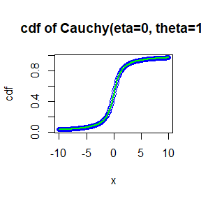

```r
#standard Cauchy ditribution
eta <- 0
theta <- 1
x<-seq(-10,10,0.1)
plot(x,cdf(x,eta,theta), lwd = 0.5,ylab="cdf",col="blue",main="cdf of Cauchy(eta=0, theta=1)")
curve(pcauchy(x,location = 0, scale = 1),add=TRUE,lwd = 2,col="green")
```

As for this graphy,We can see the two curves are cosistent,which can explain that this function can be a approximation with the R function pcauchy.

## Question

A-B-O blood type problem

$\blacktriangleright$ Let the three alleles be A, B, and O.

| Genotype | AA | BB | OO | AO | BO | AB |
| --- | --- | --- | --- | --- | --- | --- |
| Frenquency | p^2 | q^2 | r^2 | 2pr | 2qr | 2pq |
| Count | $n_{AA}$ | $n_{BB}$ | $n_{OO}$ | $n_{AO}$ | $n_{BO}$ | $n_{AB}$ |

$\blacktriangleright$ Observed data: $n_{A??} = n_{AA} + n_{AO} = 28 ~~~(A-type),$

$n_{B??} = n_{BB} + n_{BO} = 24 ~~(B-type), n_{OO} = 41~~ (O-type), n_{AB} = 70 ~~(AB-type).$

$\blacktriangleright$ Use EM algorithm to solve MLE of p and q (consider missing data $n_{AA} and n_{BB}$).

$\blacktriangleright$ Record the maximum likelihood values in M-steps, are they increasing?

## Including Plots

First, we show you the complete data likelihood and with the initial parameters $\hat{p}_0,~\hat{q}_0$ we give you the fomulation of one step MLES.

Complete data likelihood:
$$L(p,q|n_{AA},n_{BB},n_{OO},n_{AO},n_{BO},n_{AB})=(p^2)^{n_{AA}}(q^2)^{n_{BB}}(r^2)^{n_{OO}}(2pr)^{n_{AO}}(2qr)^{n_{BO}}(2pq)^{n_{AB}},$$
$$l(p,q|n_{AA},n_{BB},n_{OO},n_{AO},n_{BO},n_{AB})=n_{A\cdot}log(pr)+n_{AA}log(p/r)+n_{B\cdot}log(qr)+n_{BB}log(q/r)+2n_{OO}log(r)+n_{AB}log(pq),$$
$$E_{(\hat{p}_0,\hat{q}_0)}[l(p,q|n_{AA},n_{BB},n_{OO},n_{AO},n_{BO},n_{AB})]=n_{A\cdot}log(pr)+n_{A\cdot}\frac{\hat{p}_0}{2-\hat{p}_0-2\hat{q}_0}log(p/r)+n_{B\cdot}log(qr)+n_{B\cdot}\frac{\hat{q}_0}{2-2\hat{p}_0-\hat{q}_0}log(q/r)+2n_{OO}log(r)+n_{AB}log(pq),$$
where $\hat{p}_0$ and $\hat{q}_0$ are two initial parameters.

Define $a_0=\frac{\hat{p}_0}{2-\hat{p}_0-2\hat{q}_0}$ and $b_0=\frac{\hat{q}_0}{2-2\hat{p}_0-\hat{q}_0}$, we can simplify the expectation equation:
$$E_{(\hat{p}_0,\hat{q}_0)}[l(p,q|n_{AA},n_{BB},n_{OO},n_{AO},n_{BO},n_{AB})]=[n_{A\cdot}(1+a_0)+n_{AB}]log(p)+[n_{A\cdot}(1-a_0)+n_{B\cdot}(1-b_0)+2n_{OO}]log(r)+[n_{B\cdot}(1+b_0)+n_{AB}]log(q).$$
Then maximize the expectation equation, we obtain MLEs $\hat{p}_1,~\hat{q}_1$:
$$\hat{p}_1=\frac{H_p}{H_p+H_q+H_{pq}},~~\hat{q}_1=\frac{H_q}{H_p+H_q+H_{pq}},$$
where $H_p=n_{A\cdot}(1+a_0)+n_{AB}$, $H_1=n_{B\cdot}(1+b_0)+n_{AB}$ and $H_{pq}=n_{A\cdot}(1-a_0)+n_{B\cdot}(1-b_0)+2n_{OO}$.

Next, we use EM algorithm to solve MLE of $p$ and $q$.

```r
set.seed(123)
nA<-28
nB<-24
nOO<-41
nAB<-70  #observed data

tol <- .Machine$double.eps^0.5
N <- 10000 #max. number of iterations
p0<-0.2
q0<-0.2   #initial estimates
p<-p0
q<-q0
L<-numeric(N) #Record the maximum likelihood values in M-steps
k<-1  #Record the circle times

for (i in 1:N) {
a<-p/(2-p-2*q)
b<-q/(2-2*p-q)
Hp=nA*(1+a)+nAB
Hq=nB*(1+b)+nAB
Hpq=nA*(1-a)+nB*(1-b)+2*nOO

L[i]<-Hp*log(p)+Hpq*log(1-p-q)+Hq*log(q) #Record the    maximum likelihood values in M-steps

x<-p
y<-q                #storage previous estimates
p<-Hp/(Hp+Hq+Hpq)
q<-Hq/(Hp+Hq+Hpq)
k<-k+1

if (abs(p-x)/x<tol && abs(q-y)/y<tol) break
p.hat<-p
q.hat<-q
L<-L[1:k]
}
p.hat
```

```
## [1] 0.3273442
```

```r
q.hat
```

```
## [1] 0.3104267
```

```r
L
```

```
##  [1] -385.6238 -357.6570 -357.4552 -357.4672 -357.4698 -357.4702 -357.4703
##  [8] -357.4703 -357.4703 -357.4703
```

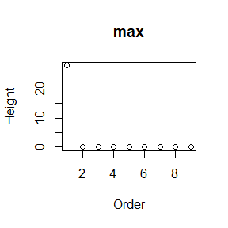

```r
d<-L[c(2:length(L))]-L[c(1:(length(L)-1))]
plot(1:9, d, main = "max", xlab = "Order", ylab = "Height")
```

## homework 2018-12-14

## Question 1

Make a faster version of chisq.test() that only computes the chi-squareteststatisticwhentheinputistwonumericvectors with no missing values. You can try simplifying chisq.test() or by coding from the mathematical de???nition (http://en. wikipedia.org/wiki/Pearson%27s_chi-squared_test).

## Answer

```r
library("MASS")
m <- length(Cars93)
# Create a data frame from the main data set.
car.data1 <- rbind(Cars93$AirBags, Cars93$Type)

# Create a table with the needed variables.
car.data2 <- table(Cars93$AirBags, Cars93$Type)


# Perform the Chi-Square test.
```

[output not shown]

## Question 2

```
Can you make a faster version of table() for the case of an input of two integer vectors with no missing values? Can you use it to speed up your chi-square test?
```

## Answer

```r
library(microbenchmark)

sample_rows <- function(df, i) sample.int(nrow(df), i, replace = TRUE)

boot_cor1 <- function(df, i) { sub <- df[sample_rows(df, i), , drop = FALSE]
table(sub$x, sub$y) }

boot_cor2 <- function(df, i ) { idx <- sample_rows(df, i)
table(df$x[idx], df$y[idx]) }
df <- data.frame(x = runif(100), y = runif(100))
microbenchmark(
  boot_cor1(df, 10),
  boot_cor2(df, 10)
)
```

```
## Unit: microseconds
##               expr     min      lq     mean  median       uq      max
##  boot_cor1(df, 10) 738.558 832.643 1298.092 928.223 1199.570 10750.79
##  boot_cor2(df, 10) 602.137 694.724 1153.558 771.702 1004.987 16018.20
##  neval
##    100
##    100
```

As for the result,we can see when working with rows from a data frame, it??s often faster to work with row indices than data frames.